# Coins problems and answers

Suppose you flip a fair coin 10 times.

2. What’s the single most likely possible outcome?

$X=5$ is most likely.

You can determine this either by symmetry arguments based on the binomial coefficient. Or you can do it by differentiating the probability mass function with respect to $X$. Or finally, you can use R to determine this numerically.

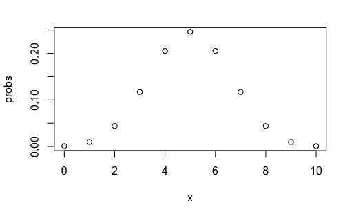

```r
x <- 0:10
n <- 10
theta <- 0.5
probs <- dbinom(x, n, theta)
plot(x, probs)
```

3. What’s the probability you obtain 9 or more heads?

The easiest way to determine this is via the cdf:

$Pr(X\geq 9) = 1 - F_X(8)$

This can be answered in R using:

```r
1 - pbinom(8, 10, 0.5)
```

```
[1] 0.01074219
```

4. Given that you know 3 or more heads have been obtained, what’s the probability that you have more than 5 heads?

This is a conditional probability:

$Pr(X > 5 | X \geq 3) = \frac{Pr(X > 5 \cap X \geq 3)}{Pr(X \geq 3)}= \frac{Pr(X > 5)}{Pr(X \geq 3)} = \frac{1-F_X(5)}{1-F_X(2)}$

which we can obtain in R using:

```r
(1 - pbinom(5, 10, 0.5)) / (1 - pbinom(2, 10, 0.5))
```

```
[1] 0.3987603
```

5. what’s the minimum number of fair coin flips needed to ensure that the chance of obtaining more than 5 heads exceeds 99%?

```r
n <- seq(10, 100, 1)
prob_exceeds_5 <- function(n) {1 - pbinom(5, n, 0.5)}
idx <- which(prob_exceeds_5(n) > 0.99)[1]
print(paste0("min number of flips = ", n[idx]))
```

```
[1] "min number of flips = 22"
```